# Unveiling Corporate Titans: Navigating Global Business Landscapes through Python Data Analysis

**Analyzing Top Companies in the World with Python and Pandas**

Author

Affiliations

John Karuitha

Karatina University, School of Business

Graduate School of Business Administration, University of the Witwatersrand

Published

August 9, 2023

Modified

August 9, 2023

# 1 **Background**

In this analysis, we use data from Kagle(Kagle, 2023) to illustrate the use of Python and Pandas in data analysis(VanderPlas, 2016). The data captures the top 2000 companies in the world and is available for free upon registration on the [Kagle website](https://www.kaggle.com/datasets/joebeachcapital/top-2000-companies-globally).

# 2 **Objectives**

The primary goal of this exercise is to illustrate how to use Python, pandas and other libraries in Python programming to analyse data for meaningful insights.

Specifically, we seek to;

1. Rank companies by their performance.
2. Rank countries and continents based on the concentration of large companies.
3. Compute the correlation between company size (in terms of assets) and financial performance.
4. Uncover regional patterns in company performance based on continent.
5. Establish the companies, continents with the highest returns on assets and profit margins.

# 3 **Summary of Results**

1. Most large companies in the sample are located in the United States.
2. The continent with the highest number of large companies is Asia.
3. There is a positive relationship between company size and financial performance (sales, profits, market value). However, this relationship varies across continents.
4. Companies from North America and Asia have the highest sales and profits.
5. Companies from Europe and Asia have the highest asset base.
6. Companies in Africa and North America are more efficient in converting sales and assets into profits.

**Tip**

Please visit my [rpubs site](www.rpubs.com/Karuitha) to see more data projects. Alternatively, copy and paste the link <www.rpubs.com/Karuitha> into your browser. You can also view my [linkedin](www.linkedin.com/in/Karuitha) site for my skills and education.

My [Tableau public profile](https://public.tableau.com/app/profile/john.karuitha) contains my data visualizations.

My Shiny web apps are available on this [site](https://karuitha.shinyapps.io/). You can copy-paste this web address instead https://karuitha.shinyapps.io/

Skills & Technologies Applied: Python, Pandas, Geopandas, Matplotlib, Quarto, Data Science.

# 4 **Data**

The data is available on [kagle](https://www.kaggle.com/datasets/joebeachcapital/top-2000-companies-globally) as a csv file (registration is required to access the data). I start by loading the necessary packages for the analysis: pandas, numpy, matplotlib, and seaborn (Borjigin, 2023).

```python
import pandas as pd
import numpy as np
import matplotlib.pyplot as plt
import seaborn as sns
import geopandas as gpd
from shapely.geometry import Point
```

Next I read in the data using pandas and set the index column as the name of the company given it is a unique and meaningful identifier.

````markdown
```{python}
company = pd.read_csv("Top2000CompaniesGlobally.csv",
index_col = "Company")

company.columns
```
````

```
Index(['Global Rank', 'Sales ($billion)', 'Profits ($billion)',
       'Assets ($billion)', 'Market Value ($billion)', 'Country', 'Continent',
       'Latitude', 'Longitude'],
      dtype='object')
```

Next, I rename the columns using names that are easier to work with. I create a dictionary of old names versus new names and then rename the columns.

````markdown
```{python}
## Create a dictionary of old names vs new names
names = {'Global Rank':'rank',
'Sales ($billion)':'sales',
'Profits ($billion)':'profits',
'Assets ($billion)':'assets',
'Market Value ($billion)':'market_value',
'Country':'country',
'Continent':'continent',
'Latitude':'latitude',
'Longitude':'longitude'}

# Rename the columns in place
company.rename(columns = names, inplace = True)
```
````

# 5 **Data Exploration**

We now explore the data.

## 5.1 Number of rows and columns

We start with the number of rows and columns in the data.

````markdown
```{python}
company.shape
```
````

```
(1924, 9)
```

We see that the data has 1924 rows (records) and 9 columns (variables).

## 5.2 First and Last Rows of the Data

Next, lets examine the first 5 rows.

````markdown
```{python}
company.head(5)
```
````

| Company | rank | sales | profits | assets | market_value | country | continent | latitude | longitude |
| --- | --- | --- | --- | --- | --- | --- | --- | --- | --- |
| ICBC | 1 | 134.8 | 37.8 | 2813.5 | 237.3 | China | Asia | 35.86166 | 104.195397 |
| China Construction Bank | 2 | 113.1 | 30.6 | 2241.0 | 202.0 | China | Asia | 35.86166 | 104.195397 |
| JPMorgan Chase | 3 | 108.2 | 21.3 | 2359.1 | 191.4 | USA | North America | 37.09024 | -95.712891 |
| General Electric | 4 | 147.4 | 13.6 | 685.3 | 243.7 | USA | North America | 37.09024 | -95.712891 |
| Exxon Mobil | 5 | 420.7 | 44.9 | 333.8 | 400.4 | USA | North America | 37.09024 | -95.712891 |

We also check the last 7 rows.

````markdown
```{python}
company.tail(7)
```
````

| Company | rank | sales | profits | assets | market_value | country | continent | latitude | longitude |
| --- | --- | --- | --- | --- | --- | --- | --- | --- | --- |
| Health Net | 1993 | 11.3 | 0.1 | 3.9 | 2.3 | USA | North America | 37.090240 | -95.712891 |
| Bank of Saga | 1994 | 0.5 | 0.0 | 25.0 | 0.4 | Japan | Asia | 36.204824 | 138.252924 |
| Tractor Supply | 1995 | 4.7 | 0.3 | 1.7 | 7.1 | USA | North America | 37.090240 | -95.712891 |
| San-Ai Oil | 1996 | 0.5 | 0.1 | 25.7 | 0.5 | Japan | Asia | 36.204824 | 138.252924 |
| UOL Group | 1996 | 0.9 | 0.7 | 7.8 | 4.2 | Singapore | Asia | 1.352083 | 103.819836 |
| Interconexion Electrica | 1998 | 2.4 | 0.2 | 14.6 | 5.8 | Colombia | South America | 4.570868 | -74.297333 |
| Old Republic International | 1999 | 5.0 | -0.1 | 16.2 | 3.3 | USA | North America | 37.090240 | -95.712891 |

## 5.3 Visual Summary

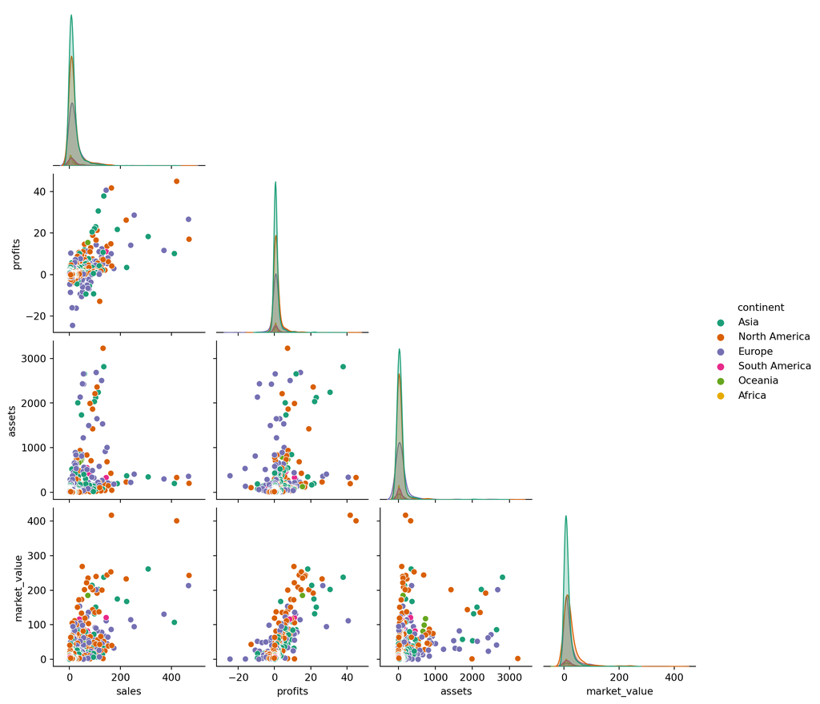

Pairs plots for the Variables (A)

````markdown
```{python}
#| fig-cap: "Pairs plots for the Variables (A)"
sns.pairplot(company[['country', 'continent', 'sales', 'profits', 'assets', 'market_value']], hue = "continent", corner = True, palette = "Dark2", kind = "scatter")
```
````

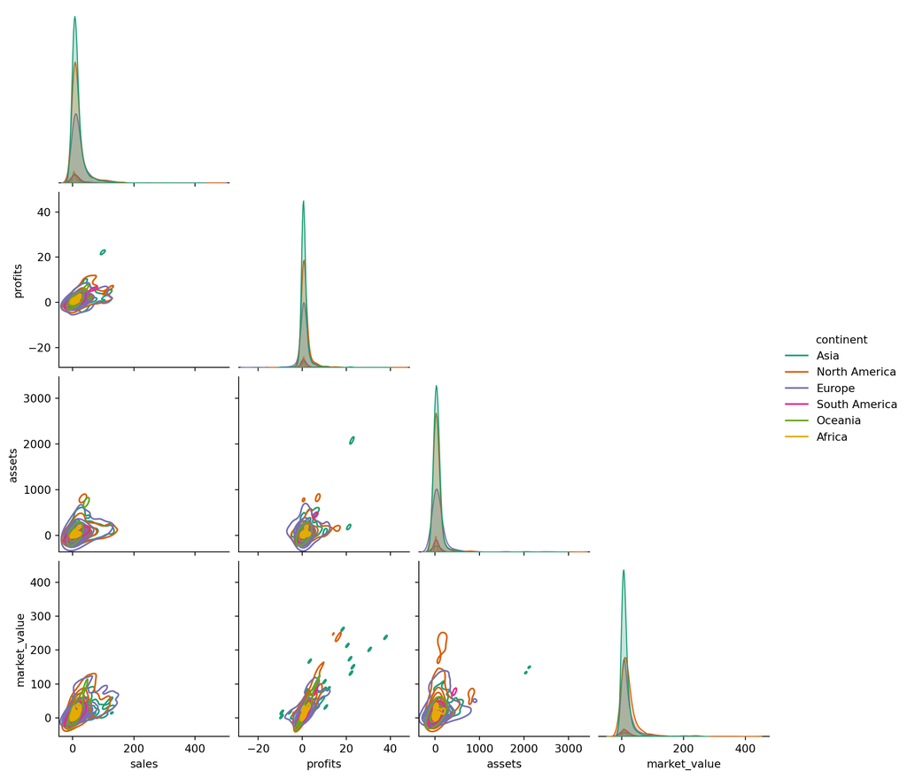

Pairs plots for the Variables (B)

````markdown
```{python}
#| fig-cap: "Pairs plots for the Variables (B)"
sns.pairplot(company[['country', 'continent', 'sales', 'profits', 'assets', 'market_value']], hue = "continent", corner = True, palette = "Dark2", kind = "kde")
```
````

## 5.4 Variable Types

The variable types are also an important data component.

````markdown
```{python}
company.info()
```
````

```
<class 'pandas.core.frame.DataFrame'>
Index: 1924 entries, ICBC to Old Republic International
Data columns (total 9 columns):
 #   Column        Non-Null Count  Dtype
---  ------        --------------  -----
 0   rank          1924 non-null   int64
 1   sales         1924 non-null   float64
 2   profits       1924 non-null   float64
 3   assets        1924 non-null   float64
 4   market_value  1924 non-null   float64
 5   country       1924 non-null   object
 6   continent     1924 non-null   object
 7   latitude      1924 non-null   float64
 8   longitude     1924 non-null   float64
dtypes: float64(6), int64(1), object(2)
memory usage: 214.9+ KB
```

````markdown
```{python}
company.dtypes
```
````

```
rank              int64
sales           float64
profits         float64
assets          float64
market_value    float64
country          object
continent        object
latitude        float64
longitude       float64
dtype: object
```

## 5.5 Missing Values

Let us check the data for any missing values for sales, profits, assets, market_value, longitude, and latitude.

````markdown
```{python}
company[company['sales'].isna()]
```
````

|  | rank | sales | profits | assets | market_value | country | continent | latitude | longitude |
| --- | --- | --- | --- | --- | --- | --- | --- | --- | --- |
| Company |  |  |  |  |  |  |  |  |  |

````markdown
```{python}
company[company['profits'].isna()]
```
````

|  | rank | sales | profits | assets | market_value | country | continent | latitude | longitude |
| --- | --- | --- | --- | --- | --- | --- | --- | --- | --- |
| Company |  |  |  |  |  |  |  |  |  |

````markdown
```{python}
company[company['assets'].isna()]
```
````

|  | rank | sales | profits | assets | market_value | country | continent | latitude | longitude |
| --- | --- | --- | --- | --- | --- | --- | --- | --- | --- |
| Company |  |  |  |  |  |  |  |  |  |

````markdown
```{python}
company[company['market_value'].isna()]
```
````

|  | rank | sales | profits | assets | market_value | country | continent | latitude | longitude |
| --- | --- | --- | --- | --- | --- | --- | --- | --- | --- |
| Company |  |  |  |  |  |  |  |  |  |

````markdown
```{python}
company[company['longitude'].isna()]
```
````

|  | rank | sales | profits | assets | market_value | country | continent | latitude | longitude |
| --- | --- | --- | --- | --- | --- | --- | --- | --- | --- |
| Company |  |  |  |  |  |  |  |  |  |

````markdown
```{python}
company[company['latitude'].isna()]
```
````

|  | rank | sales | profits | assets | market_value | country | continent | latitude | longitude |
| --- | --- | --- | --- | --- | --- | --- | --- | --- | --- |
| Company |  |  |  |  |  |  |  |  |  |

This is a conveniently clean data without missing values which is a rare occurrence in data science.

## 5.6 Summary Statistics

We use the describe method to make summary statistics for numeric and character variables separately.

````markdown
```{python}
company.describe(include = "float64")
```
````

|  | sales | profits | assets | market_value | latitude | longitude |
| --- | --- | --- | --- | --- | --- | --- |
| count | 1924.000000 | 1924.000000 | 1924.000000 | 1924.000000 | 1924.000000 | 1924.000000 |
| mean | 19.265904 | 1.226040 | 79.507796 | 19.558160 | 34.618747 | 15.455664 |
| std | 34.683911 | 3.413831 | 261.098775 | 32.957023 | 18.259499 | 92.639655 |
| min | 0.000000 | -24.500000 | 1.000000 | 0.000000 | -40.900557 | -106.346771 |
| 25% | 4.100000 | 0.300000 | 9.675000 | 5.300000 | 35.861660 | -95.712891 |
| 50% | 9.000000 | 0.600000 | 19.250000 | 9.600000 | 37.090240 | 10.451526 |
| 75% | 18.425000 | 1.200000 | 45.800000 | 19.200000 | 40.463667 | 105.318756 |
| max | 469.200000 | 44.900000 | 3226.200000 | 416.600000 | 61.924110 | 174.885971 |

We also do the same for string data types.

````markdown
```{python}
company.describe(include = "object")
```
````

|  | country | continent |
| --- | --- | --- |
| count | 1924 | 1924 |
| unique | 60 | 6 |
| top | USA | Asia |
| freq | 535 | 719 |

Here we see that there are 1924 observations with 60 unique countries across 6 continents. The country with the most companies is the USA (535), while the continent with the most companies is Asia (719).

# 6 Analysis

In this section, we explore some key issues from the data, listed in order.

## 6.1 **Which Companies are the Best Performing in the Sample Data?**

We start by examining sales. Wal-mart and Shell lead the pack in this case. Overall petroleum companies and motor vehicle manufacturing companies do very well.

````markdown
```{python}
company.nlargest(10, "sales")["sales"]
```
````

```
Company
Wal-Mart Stores            469.2
Royal Dutch Shell          467.2
Exxon Mobil                420.7
Sinopec-China Petroleum    411.7
BP                         370.9
PetroChina                 308.9
Volkswagen Group           254.0
Total                      240.5
Toyota Motor               224.5
Chevron                    222.6
Name: sales, dtype: float64
```

In terms of profits, Exxon Mobil and Apple come up tops.

````markdown
```{python}
company.nlargest(10, "profits")["profits"]
```
````

```
Company
Exxon Mobil                   44.9
Apple                         41.7
Gazprom                       40.6
ICBC                          37.8
China Construction Bank       30.6
Volkswagen Group              28.6
Royal Dutch Shell             26.6
Chevron                       26.2
Agricultural Bank of China    23.0
Bank of China                 22.1
Name: profits, dtype: float64
```

Apple tops the ranking of most valuable company followed by Exxon Mobil and Google.

````markdown
```{python}
company.nlargest(10, "market_value")["market_value"]
```
````

```
Company
Apple                 416.6
Exxon Mobil           400.4
Google                268.4
PetroChina            261.2
Berkshire Hathaway    252.8
General Electric      243.7
Wal-Mart Stores       242.5
IBM                   239.5
ICBC                  237.3
Microsoft             234.8
Name: market_value, dtype: float64
```

## 6.2 Which Countries and Continents Have the Highest Concentration of Large Companies?

In this section, we utilize the global rank in size variable to identify the countries and continents with the highest number of top-ranking companies. We see that companies from USA, Japan, China, UK, Canada, and South Korea dominate the rankings. Note that these are countries mainly from North America and Asia (with the exception of the UK) which illustrates the dominance of these two continents in global trade.

````markdown
```{python}
company['country'].value_counts()
```
````

```
USA                     535
Japan                   246
China                   135
UK                       97
Canada                   65
South Korea              64
France                   64
India                    56
Germany                  50
Hong Kong                46
Australia                42
Taiwan                   40
Brazil                   31
Russia                   30
Italy                    29
Spain                    28
Sweden                   26
The Netherlands          24
Singapore                20
Malaysia                 20
South Africa             19
Mexico                   19
Saudi Arabia             17
Ireland                  17
Thailand                 16
Turkey                   14
United Arab Emirates     14
Finland                  12
Belgium                  11
Norway                   10
Denmark                  10
Israel                   10
Greece                   10
Indonesia                 9
Chile                     9
Bermuda                   9
Philippines               8
Qatar                     8
Poland                    8
Luxembourg                7
Colombia                  6
Portugal                  6
Kuwait                    4
Hungary                   2
Peru                      2
Morocco                   2
Kazakhstan                2
Egypt                     2
Lebanon                   2
Pakistan                  1
Vietnam                   1
Channel Islands           1
Oman                      1
Nigeria                   1
Jordan                    1
Liberia                   1
Venezuela                 1
Panama                    1
Czech Republic            1
New Zealand               1
Name: country, dtype: int64
```

Just to confirm, let us see the concentration of companies by continent.

````markdown
```{python}
company['continent'].value_counts()
```
````

```
Asia             719
North America    629
Europe           459
South America     49
Oceania           43
Africa            25
Name: continent, dtype: int64
```

We then visualize this information on a world map using latitude and longitude data to show the geographic distribution of these companies. The size of the dots represents profits. We find that while there are the profitable companies are mainly in Asia, Europe, and North America. The rest of the world generates very few profits.

````markdown
```{python}
# Create a GeoDataFrame
geometry = [Point(lon, lat) for lon, lat in zip(company['longitude'], company['latitude'])]
gdf = gpd.GeoDataFrame(company, geometry=geometry, columns=['company', 'sales', 'profits', 'assets'])
```
````

````markdown
```{python}
world = gpd.read_file(gpd.datasets.get_path('naturalearth_lowres'))
```
````

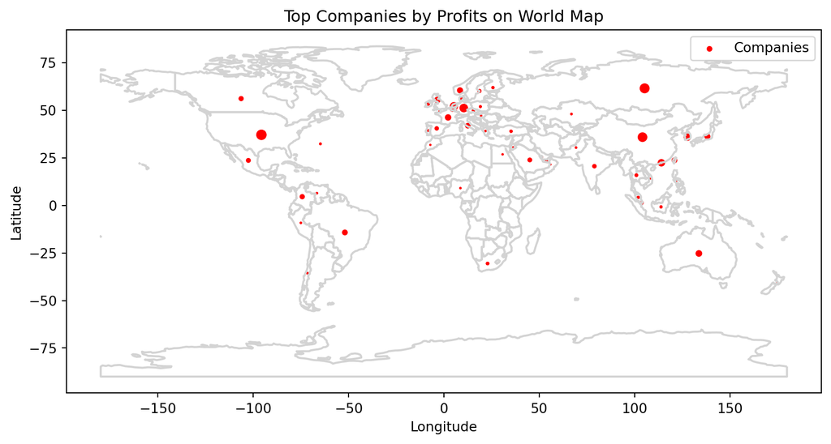

````markdown
```{python}
#| fig-cap: "Top Companies by Sales on a World Map"
# Create a subplot
fig, ax = plt.subplots(figsize=(10, 10))

# Plot the world map
world.boundary.plot(ax=ax, color = "lightgrey")

# Plot your data on the map
gdf.plot(ax=ax, marker='o', color='red', markersize='profits', label='Companies')

# Add labels and legend
ax.set_title('Top Companies by Profits on World Map')
ax.set_xlabel('Longitude')
ax.set_ylabel('Latitude')
ax.legend()

plt.show()
```
````

## 6.3 Is There a Correlation Between Company Size (in terms of assets) and Financial Performance?

Here, we analyze the relationship between the asset base of companies, which is a proxy for size and financial metrics such as sales, profits, and market value. The goal is to determine if larger companies tend to have higher sales, profits, and market value, or if there are exceptions. Overall, there appears to be a positive link between the size of a company and its financial performance in terms of sales, profits, and market value. However, this relationship varies by continent.

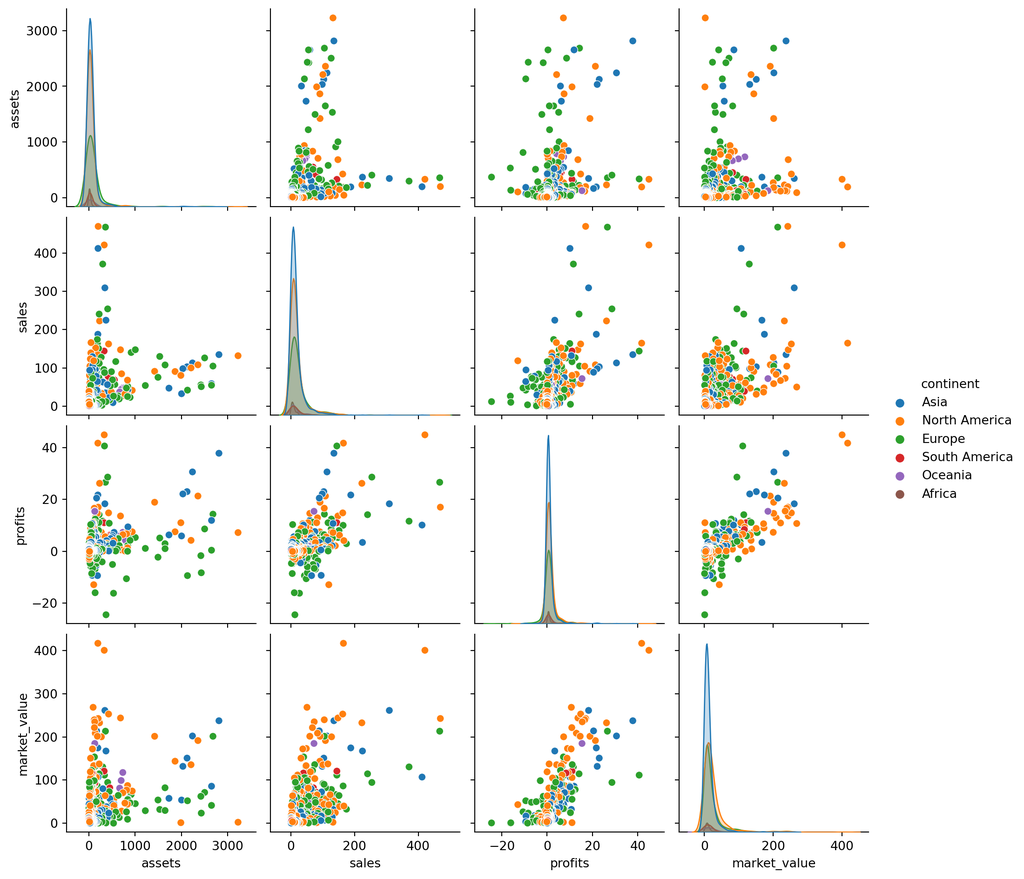

Pairs plots for the Variables (C)

````markdown
```{python}
#| fig-cap: "Pairs plots for the Variables (C)"
sns.pairplot(company[["continent", "assets", "sales", "profits", "market_value"]], hue = "continent")
```
````

````markdown
```{python}
company[["assets", "sales", "profits", "market_value"]].corr()
```
````

|  | assets | sales | profits | market_value |
| --- | --- | --- | --- | --- |
| assets | 1.000000 | 0.356069 | 0.356553 | 0.375544 |
| sales | 0.356069 | 1.000000 | 0.594174 | 0.649493 |
| profits | 0.356553 | 0.594174 | 1.000000 | 0.788853 |
| market_value | 0.375544 | 0.649493 | 0.788853 | 1.000000 |

## 6.4 Are There Regional Patterns in Company Performance Based on Continent?

Sales by Companies

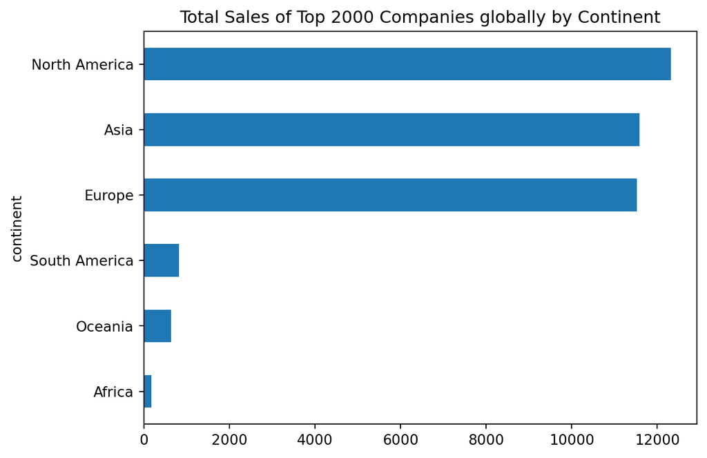

````markdown
```{python}
#| fig-cap: "Sales by Companies"
company.groupby("continent")["sales"].sum().sort_values().plot(kind = "barh", title = "Total Sales of Top 2000 Companies globally by Continent")
```
````

Total Profits of Top 2000 Companies globally by Continent

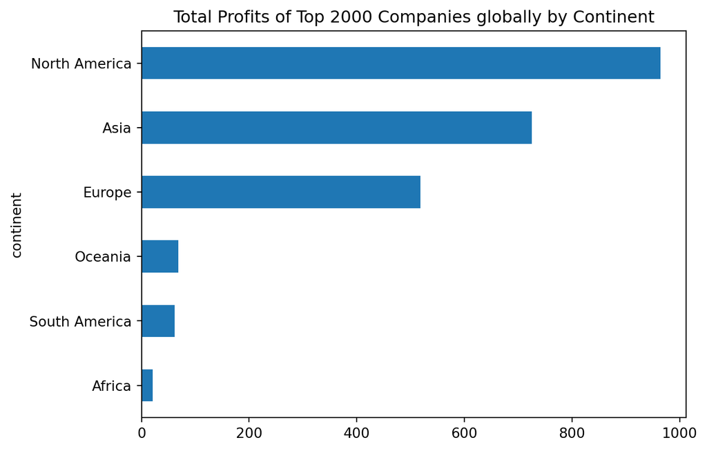

````markdown
```{python}
#| fig-cap: "Total Profits of Top 2000 Companies globally by Continent"
company.groupby("continent")["profits"].sum().sort_values().plot(kind = "barh", title = "Total Profits of Top 2000 Companies globally by Continent")
```
````

Total Assets of Top 2000 Companies globally by Continent

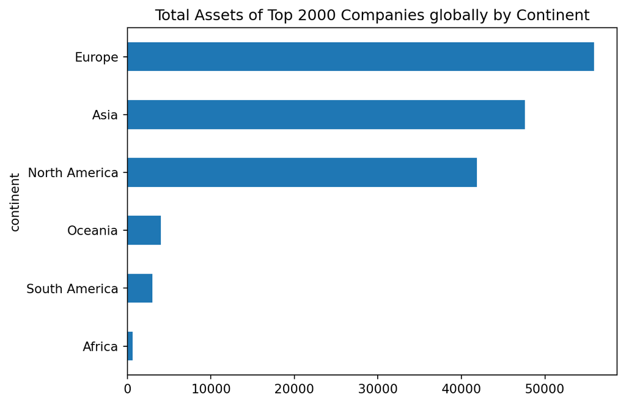

````markdown
```{python}
#| fig-cap: "Total Assets of Top 2000 Companies globally by Continent"
company.groupby("continent")["assets"].sum().sort_values().plot(kind = "barh", title = "Total Assets of Top 2000 Companies globally by Continent")
```
````

## 6.5 Which Companies, Contiments have the Highest Returns on Assets and Profit margins?

The return on assets is the ratio of profits to assets and captures the efficiency with which a company utilises its assets to generate profits. The net profit margin also captures how well a company is able to convert its sales into profits. The margin can also proxy the management efforts towards expenses management.

Carphone Warehouse with a return on assets of 1 means that it generated profits equivalent to its assets base. This is phenomenal!! The companies in the top 5 all have a return greater than 30%, which is an exceptional performance.

````markdown
```{python}
company["roa"] = company["profits"] / company["assets"]
company["margin"] = company["profits"] / company["sales"]
```
````

````markdown
```{python}
company['roa'].sort_values(ascending = False).head()
```
````

```
Company
Carphone Warehouse           1.000000
Regeneron Pharmaceuticals    0.470588
Alexander's                  0.466667
Saudi Arabian Fertilizers    0.370370
Seagate Technology           0.367816
Name: roa, dtype: float64
```

Next, I compute the median ROA for each continent. Africa leads, though the continent has very few companies in the sample. North America is in second place, which implies that the companies in this continent are very efficient in utilizing assets to generate profits.

````markdown
```{python}
company.groupby("continent")['roa'].median().sort_values(ascending = False)
```
````

```
continent
Africa           0.063492
North America    0.046512
Oceania          0.046512
Europe           0.034483
South America    0.024590
Asia             0.021583
Name: roa, dtype: float64
```

Let us do the same for profit margin. The companies in the top 5 have ratios greater than 1 which implies they generated profits greater than the sales. This is cause for concern especially for Carphone Warehouse which appears to have generated profits from zero sales.

````markdown
```{python}
company['margin'].sort_values(ascending = False).head()
```
````

```
Company
Carphone Warehouse         inf
Hysan Development     4.333333
Industrivarden        4.250000
Alexander's           3.500000
Chinese Estates       3.250000
Name: margin, dtype: float64
```

Africa leads in median profit margin. Again this could be die to the low number of companies from the continent in this sample. Oceania and North America follow in that order. Europe does poorly.

````markdown
```{python}
company.groupby("continent")['margin'].median().sort_values(ascending = False)
```
````

```
continent
Africa           0.139423
Oceania          0.107143
North America    0.090909
South America    0.083333
Asia             0.072289
Europe           0.060185
Name: margin, dtype: float64
```

# 7 **Conclusion**

In this analysis, we use data from Kagle to illustrate the use of Python and Pandas in data analysis. From the analysis, we find that;

1. Most large companies in the sample are located in the United States.
2. The continent with the highest number of large companies is Asia.
3. There is a positive relationship between company size and financial performance. However, this relationship varies across continents.
4. Companies from North America and Asia have the highest sales and profits.
5. Companies from Europe and Asia have the highest asset base.
6. Companies in Africa and North America are more efficient in converting sales and assets into profits.

## References

Borjigin, C. (2023). *Python data science*. Springer Nature Singapore. https://doi.org/10.1007/978-981-19-7702-2

Kagle. (2023). *Top 2000 companies globally*. https://www.kaggle.com/datasets/joebeachcapital/top-2000-companies-globally.

VanderPlas, J. (2016). *Python data science handbook: Essential tools for working with data*. " O’Reilly Media, Inc.".